# To-do Geral

- Grid search random com dados não balanceados
- Treinar modelos com dados balanceados
- Grid seach random para os dados balanceados

```python
%matplotlib inline
import pandas as pd
import matplotlib.pyplot as plt
import numpy as np
import seaborn as sns
import warnings
warnings.filterwarnings('ignore')

import codeclub_mails as ccm
```

```
:0: FutureWarning: IPython widgets are experimental and may change in the future.
```

```python
emails = pd.read_csv("base3.csv", encoding=None)
```

```
Number of examples:  891
Number of labels (Multilabel):  12

Label proportion:
criar clube: 27.27%
contato clube: 15.71%
parceria: 3.48%
voluntario geral: 28.96%
Local busca voluntario: 0.56%
Voluntario busca local: 2.58%
Como funciona: 19.98%
Apresentar projeto: 6.62%
Crianca quer clube: 4.49%
Material: 9.32%
Precisa de um humano: 16.50%
Treinamento: 1.35%
```

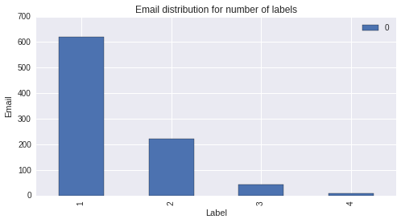

```
Co-occurence Matrix

[[243  10   6  15   0   3  49  29   2  27   6   2]
 [ 10 140   1  27   0   8  15   3  14   3   3   3]
 [  6   1  31   1   1   0  10   1   0   2   9   0]
 [ 15  27   1 258   1   8  22   5   2   9   2   2]
 [  0   0   1   1   5   0   1   0   0   0   1   0]
 [  3   8   0   8   0  23   7   2   0   0   0   0]
 [ 49  15  10  22   1   7 178  14   6  25   9   3]
 [ 29   3   1   5   0   2  14  59   4   9   2   3]
 [  2  14   0   2   0   0   6   4  40   0   0   0]
 [ 27   3   2   9   0   0  25   9   0  83   2   3]
 [  6   3   9   2   1   0   9   2   0   2 147   0]
 [  2   3   0   2   0   0   3   3   0   3   0  12]]
```

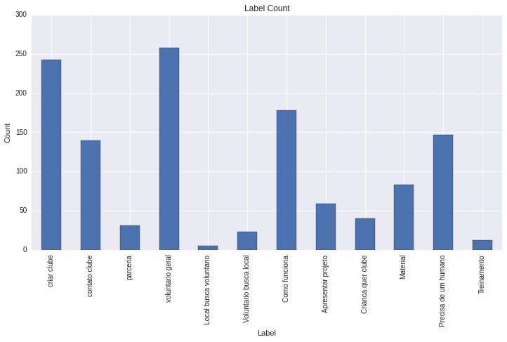

```
None


Message example:
Caro Contato,

Gostaria de saber se já existe algum clube ou responsável em Belo Horizonte?
Senão, gostaria muito de participar!

Att,
```

```python
#Data profile
print "Number of examples: ", emails.shape[0]
print "Number of labels (Multilabel): ", len(emails.columns[3:])
print "\nLabel proportion: "
for column in emails.columns[3:]:
    print column + ": %.2f" % float(emails[column].value_counts(normalize=True).values[1]*100) + "%"

#Count number of labels
n_classes = len(emails.columns[3:])
class_names = emails.columns[3:]
emails["n_labels"] = emails.apply(lambda x : x[class_names].sum(), axis=1)
bar = pd.DataFrame(emails["n_labels"].convert_objects(convert_numeric=True).value_counts())
bar = bar.sort()
ax = bar.plot(kind='bar', figsize=(8, 4))
plt.ylabel("Email")
plt.xlabel("Label")
plt.title('Email distribution for number of labels')
plt.show()

#Co-occurence matrix
print "Co-occurence Matrix \n"
df_labels = emails[class_names].astype(int)
coocc = df_labels.T.dot(df_labels)
#print coocc.columns.values
print coocc.values

#Label Histogram
def multilabel_histogram(target_matrix, column_names):
    plt.figure(figsize=(12,6))
    sum_positives = target_matrix.sum(axis=0)
    sum_positives.plot(kind='bar')
    plt.title("Label Count")
    plt.xlabel("Label")
    plt.ylabel("Count")
    plt.show()

print multilabel_histogram(df_labels, emails.columns)

#Example
n_example = 250
example = emails["mensagem"][n_example]
print "\n\nMessage example: \n" + example
```

# Preprocessing

preproc(message: str) -> str

1. Lower case
2. Special characters replacement
3. Eliminate ponctuation and white spaces
4. Append Subject to the body with SUBJECT_ prefix

**TO DO**

1. Part-of-Speech
2. Stop-words

```python
# Lower case, special characters replacement and ponctuation and white space elimination
import re
import unicodedata
def preproc(message):
    #print message
    message = str(message)
    message = message.lower()
    message = unicode(message, "utf-8")
    message = unicodedata.normalize("NFKD", message).encode('ascii', 'ignore').lower().replace(' ', '-')
    message = re.sub("[^a-zA-Z]", " ", message)
    message = re.sub(" +", " ", message)
    return message

#Putting a "SUBJECT_" prefix to each word in the text
def append_subj(text):
    new_text = []
    for word in text.split():
        new_text.append("SUBJECT_" + word)
    return " ".join(new_text)

#Cleaning message and subject
emails["clean_message"] = emails["mensagem"].apply(preproc)
emails["clean_subject"] = emails["assunto"].apply(preproc)

#Applying SUBJECT_ append
emails["clean_subject"] = emails["clean_subject"].apply(lambda x : append_subj(x))

#Concatenate subject to message
emails["clean_message"] = emails.apply(lambda x : str(x["clean_subject"]) + " " + str(x["clean_message"]), axis=1)

#print example
print emails["clean_message"][n_example]
```

```
SUBJECT_projeto SUBJECT_em SUBJECT_bh caro contato gostaria de saber se ja existe algum clube ou responsavel em belo horizonte senao gostaria muito de participar att
```

# Extracting Features

1. Tokens
2. Tf-Idf

**TO DO**

1. Extract N-Gram before Subject and Message concatenation

```python
from sklearn.feature_extraction.text import CountVectorizer
from sklearn.feature_extraction.text import TfidfVectorizer

vectorizer = CountVectorizer(analyzer = "word",   \
                             tokenizer = None,    \
                             preprocessor = None, \
                             stop_words = None,   \
                             ngram_range = (1, 2),   \
                             lowercase=False, \
                             max_features=1000)

tfidf_vectorizer = TfidfVectorizer(analyzer = "word",   \
                             tokenizer = None,    \
                             preprocessor = None, \
                             stop_words = None,   \
                             ngram_range = (1, 2),   \
                             lowercase=False, \
                             max_features=1000)

nchar_gram_vectorizer = CountVectorizer(analyzer='char_wb', \
                                        ngram_range=(4, 4), \
                                        min_df=2)

emails["token"] = vectorizer.fit_transform(emails["clean_message"])
emails["token-tfidf"] = tfidf_vectorizer.fit_transform(emails["clean_message"])
emails["token-char"] = nchar_gram_vectorizer.fit_transform(emails["clean_message"])

print "Tokens from example: "
print "Dictionary size: " + str(emails["token"][0].shape[1])
item = 0
for token in emails["token"][0][n_example, :].nonzero()[1]:
    print vectorizer.get_feature_names()[token] + ":",
    print str(emails["token"][0][n_example, :].data[item]) + "; ",
    item += 1

print "\n\n *** TF-IDF ***"
print "Dictionary size: " + str(emails["token-tfidf"][0].shape[1])
item = 0
for token in emails["token-tfidf"][0][n_example, :].nonzero()[1]:
    print tfidf_vectorizer.get_feature_names()[token] + ":",
    print str(emails["token-tfidf"][0][n_example, :].data[item]) + "; ",
    item += 1

print "\n\n *** N-Gram Char ***"
print "Dictionary size: " + str(emails["token-char"][0].shape[1])
item = 0
for token in emails["token-char"][0][n_example, :].nonzero()[1]:
    print nchar_gram_vectorizer.get_feature_names()[token] + ":",
    print str(emails["token-char"][0][n_example, :].data[item]) + "; ",
    item += 1
```

```
Tokens from example:
Dictionary size: 1000
de: 2;  ou: 1;  gostaria: 2;  gostaria de: 1;  em: 1;  saber: 1;  se: 1;  de saber: 1;  ja: 1;  clube: 1;  muito: 1;  att: 1;  participar: 1;  algum: 1;  contato: 1;  saber se: 1;  SUBJECT_projeto: 1;  existe: 1;  existe algum: 1;  SUBJECT_em: 1;  gostaria muito: 1;  muito de: 1;  ja existe: 1;  bel…

 *** TF-IDF ***
Dictionary size: 1000
responsavel: 0.268757024982;  de participar: 0.237693332747;  belo horizonte: 0.262142330257;  horizonte: 0.262142330257;  belo: 0.25912158909;  ja existe: 0.268757024982;  muito de: 0.23212517881;  gostaria muito: 0.237693332747;  SUBJECT_em: 0.188878637913;  existe algum: 0.248516427223;  existe: …

 *** N-Gram Char ***
Dictionary size: 6796
 sub: 3;  subj: 3;  ubje: 3;  bjec: 3;  ject: 3;  ect_: 3;  ria : 2;   de : 2;  tari: 2;   ou : 1;  onta: 1;   gos: 2;  gost: 2;  osta: 2;  star: 2;  aria: 2;   em : 1;  iste: 1;  club: 1;   sab: 1;  sabe: 1;  aber: 1;  ber : 1;   par: 1;   se : 1;  nte : 1;   sen: 1;  nao : 1;   ja : 1;   bel: 1;  …
```

## Training, validation and test set

(We'll use cross-validation!)

```python
from sklearn.cross_validation import train_test_split

#emails["token-tfidf"]
X_train, X_test, y_train, y_test = train_test_split(emails["token-tfidf"][0], emails.ix[:, 3:(n_classes + 3)],
                                                    test_size=0.1, random_state=33)
print "Training set size: " + str(X_train.shape[0])
print "Test set size: " + str(X_test.shape[0])
```

```
Training set size: 801
Test set size: 90
```

## Model Evaluation Metrics

- Global Accuracy
- Confusion Matrix
- Leave One Out
  - Accuracy, Precision and Recall
- Complete Report
  - Accuracy, Precision, Recall, F1-Score, Confusion Matrix and ROC

Global Accuracy: number of examples with all labels predicted Confusion Matrix: True N P Pred N [ TN , FN ] P [ FP, TP ]

```python
#input: y_pred a matrix of predictions, each column for each class
# y_true: matrix of true values, i data_points/row and j classes/columns
from sklearn.metrics import hamming_loss
from sklearn.metrics import confusion_matrix
from sklearn import cross_validation
from sklearn.cross_validation import cross_val_score, LeaveOneOut, KFold
from scipy.stats import sem
from sklearn import metrics

def evaluate_cross_validation(clf, X, y, K):
    cv = KFold(len(y), K, shuffle=True, random_state=0)
    # by default the score used is the one returned by score >>>
    scores = cross_val_score(clf, X, y, cv=cv)
    precisions = cross_val_score(clf, X, y, scoring='precision', cv=cv)
    recalls = cross_val_score(clf, X, y, scoring='recall', cv=cv)
    #print scores
    #print precisions
    print ("Mean score: {0:.3f} (+/-{1:.3f})").format(np.mean(scores), sem(scores))
    print ("Mean precision: {0:.3f} (+/-{1:.3f})").format(np.mean(precisions), sem(precisions))
    print ("Mean recall: {0:.3f} (+/-{1:.3f})").format(np.mean(recalls), sem(recalls))
    return np.mean(scores)

def global_accuracy(y_pred, y_true):
    globally_right = 0
    for point in range(y_true.shape[0]):
        no_miss_class = True
        for label in range(y_true.shape[1]):
            if y_pred.loc[y_true.index[point], str(emails.columns.values[label+3])] != y_true.loc[y_true.index[point],str(emails.columns.values[label+3])]:
                no_miss_class = False
        if no_miss_class:
            globally_right += 1
    return globally_right / float(y_pred.shape[0])

def confusion_matrix_for_classes(y_pred, y_true):
    for label in range(y_true.shape[1]):
        conf_matrix_one_class(y_pred, y_true, str(emails.columns.values[label+3]))

def conf_matrix_one_class(y_pred, y_true, label):
    print "---------------------------------"
    print "Confusion matrix for", label
    print "Positive predictions: ", y_pred[label].sum()
    print confusion_matrix(y_pred[label], y_true[label])
    print "---------------------------------"

def hamming_loss(y_pred, y_true):
    pass


def loo_cv(X_train, y_train, clf):
    #y_train = y_train.ix[:, 1].as_matrix()
    y_train = y_train.as_matrix()
    loo = LeaveOneOut(X_train.shape[0])
    scores = np.zeros(X_train.shape[0])
    precisions = np.zeros(X_train.shape[0])
    recalls = np.zeros(X_train.shape[0])
    for train_index, test_index in loo:
        X_train_cv, X_test_cv = X_train[train_index], X_train[test_index]
        y_train_cv, y_test_cv = y_train[train_index], y_train[test_index]
        clf = clf.fit(X_train_cv,y_train_cv)
        y_pred = clf.predict(X_test_cv)
        scores[test_index] = metrics.accuracy_score(y_test_cv.astype(int), y_pred.astype(int))
        precisions[test_index] = metrics.precision_score(y_test_cv.astype(int), y_pred.astype(int))
        recalls[test_index] = metrics.recall_score(y_test_cv.astype(int), y_pred.astype(int))
    print ("Accuracy: {0:.3f} (+/-{1:.3f})").format(np.mean(scores), sem(scores))
    print ("Precision: {0:.3f} (+/-{1:.3f})").format(np.mean(precisions), sem(precisions))
    print ("Recall: {0:.3f} (+/-{1:.3f})").format(np.mean(recalls), sem(recalls))

def complete_report(y_pred, y_test):
    print "Global Accuracy: ", global_accuracy(y_pred, y_test)
    for i in range(n_classes):
        label = str(emails.columns.values[i+3])
        print "*********************************"
        print label + ": "
        print "Accuracy: %.2f" \
        % float((y_pred[str(emails.columns.values[i+3])] == y_test[str(emails.columns.values[i+3])]).sum() / float(y_test.shape[0]))
        print "Precision: ", metrics.precision_score(y_test[str(emails.columns.values[i+3])].astype(int), y_pred[str(emails.columns.values[i+3])].astype(int))
        print "Recall: ", metrics.recall_score(y_test[str(emails.columns.values[i+3])].astype(int), y_pred[str(emails.columns.values[i+3])].astype(int))
        print "F1-Score: ", metrics.f1_score(y_test[str(emails.columns.values[i+3])].astype(int), y_pred[str(emails.columns.values[i+3])].astype(int))
        conf_matrix_one_class(y_pred, y_test, str(emails.columns.values[i+3]))
        try:
            print "Roc Area: ", metrics.roc_auc_score(y_test[str(emails.columns.values[i+3])].astype(int), y_pred[str(emails.columns.values[i+3])].astype(int))
            roc_curve_label(y_pred[str(emails.columns.values[i+3])], y_test[str(emails.columns.values[i+3])])
        except:
            print "--"
        print "*********************************"

def roc_curve_label(y_pred, y_test):
    fpr, tpr, _ = metrics.roc_curve(y_test, y_pred)
    plt.figure(1)
    plt.plot([0, 1], [0, 1], 'k--')
    plt.plot(fpr, tpr, label='RT + LR')
    plt.xlabel('False positive rate')
    plt.ylabel('True positive rate')
    plt.title('ROC curve')
    plt.legend(loc='best')
    plt.show()
```

## Baseline - Naive Bayes

```python
from sklearn.naive_bayes import GaussianNB
from sklearn.naive_bayes import MultinomialNB
gnb = MultinomialNB()

models1= []
print "Multinomial Naive-Bayer, default params (alpha=1.0, fit_prior=True, class_prior=None)\n "
for i in range(n_classes):
    models1.append(MultinomialNB())
    models1[i] = gnb.fit(X_train.toarray(), y_train[str(emails.columns.values[i+3])])
    evaluate_cross_validation(models1[i], X_train, y_train[str(emails.columns.values[i+3])], 15)
    #loo_cv(X_train.toarray(), y_train[str(emails.columns.values[i+3])], models1[i])
```

```
Multinomial Naive-Bayer, default params (alpha=1.0, fit_prior=True, class_prior=None)

Mean score: 0.794 (+/-0.014)
Mean precision: 0.883 (+/-0.040)
Mean recall: 0.292 (+/-0.031)
Mean score: 0.868 (+/-0.010)
Mean precision: 0.953 (+/-0.035)
Mean recall: 0.205 (+/-0.032)
Mean score: 0.965 (+/-0.005)
Mean precision: 0.000 (+/-0.000)
Mean recall: 0.000 (+/-0.000)
Mean score: 0.820 (+/-0.012)
Mean precision: 0.855 (+/-0.033)
Mean recall: 0.437 (+/-0.030)
Mean score: 0.995 (+/-0.003)
Mean precision: 0.000 (+/-0.000)
Mean recall: 0.000 (+/-0.000)
Mean score: 0.974 (+/-0.005)
Mean precision: 0.000 (+/-0.000)
Mean recall: 0.000 (+/-0.000)
Mean score: 0.803 (+/-0.011)
Mean precision: 0.067 (+/-0.067)
Mean recall: 0.007 (+/-0.007)
Mean score: 0.929 (+/-0.007)
Mean precision: 0.000 (+/-0.000)
Mean recall: 0.000 (+/-0.000)
Mean score: 0.955 (+/-0.007)
Mean precision: 0.000 (+/-0.000)
Mean recall: 0.000 (+/-0.000)
Mean score: 0.908 (+/-0.012)
Mean precision: 0.000 (+/-0.000)
Mean recall: 0.000 (+/-0.000)
Mean score: 0.850 (+/-0.008)
Mean precision: 0.733 (+/-0.118)
Mean recall: 0.126 (+/-0.030)
Mean score: 0.985 (+/-0.003)
Mean precision: 0.000 (+/-0.000)
Mean recall: 0.000 (+/-0.000)
```

```python
#building a vector of predictions and models, one for each class
y_pred = pd.DataFrame(index=y_test.index, columns=y_test.columns.values)
y_pred_proba = pd.DataFrame(index=y_test.index, columns=y_test.columns.values)
print "Accuracy for each label: "
for i in range(n_classes):
    y_pred[str(emails.columns.values[i+3])] = gnb.fit(X_train.toarray(), y_train[str(emails.columns.values[i+3])]).predict(X_test.toarray())
    print str(emails.columns.values[i+3]) + ": %.2f" \
    % float((y_pred[str(emails.columns.values[i+3])] == y_test[str(emails.columns.values[i+3])]).sum() / float(y_test.shape[0]))

print "\n\n *** Leave One Out ***"
for i in range(n_classes):
    print str(emails.columns.values[i+3]) + ": ",
    loo_cv(X_train.toarray(), y_train[str(emails.columns.values[i+3])], gnb)
    print "---------------------------------"
```

```
Accuracy for each label:
criar clube: 0.80
contato clube: 0.91
parceria: 0.97
voluntario geral: 0.78
Local busca voluntario: 0.99
Voluntario busca local: 0.98
Como funciona: 0.79
Apresentar projeto: 0.98
Crianca quer clube: 0.96
Material: 0.90
Precisa de um humano: 0.90
Treinamento: 1.00


 *** Leave One Out ***
criar clube:  Accuracy: 0.801 (+/-0.014)
Precision: 0.086 (+/-0.010)
Recall: 0.086 (+/-0.010)
---------------------------------
contato clube:  Accuracy: 0.868 (+/-0.012)
Precision: 0.032 (+/-0.006)
Recall: 0.032 (+/-0.006)
---------------------------------
parceria:  Accuracy: 0.965 (+/-0.006)
Precision: 0.000 (+/-0.000)
Recall: 0.000 (+/-0.000)
---------------------------------
voluntario geral:  Accuracy: 0.823 (+/-0.014)
Precision: 0.122 (+/-0.012)
Recall: 0.122 (+/-0.012)
---------------------------------
Local busca voluntario:  Accuracy: 0.995 (+/-0.002)
Precision: 0.000 (+/-0.000)
Recall: 0.000 (+/-0.000)
---------------------------------
Voluntario busca local:  Accuracy: 0.974 (+/-0.006)
Precision: 0.000 (+/-0.000)
Recall: 0.000 (+/-0.000)
---------------------------------
```

[output cut: 9 more lines]

```
Precision: 0.000 (+/-0.000)
Recall: 0.000 (+/-0.000)
---------------------------------
Material:  Accuracy: 0.910 (+/-0.010)
Precision: 0.002 (+/-0.002)
Recall: 0.002 (+/-0.002)
---------------------------------
Precisa de um humano:  Accuracy: 0.856 (+/-0.012)
Precision: 0.030 (+/-0.006)
Recall: 0.030 (+/-0.006)
---------------------------------
Treinamento:  Accuracy: 0.985 (+/-0.004)
Precision: 0.000 (+/-0.000)
Recall: 0.000 (+/-0.000)
---------------------------------
```

```
Searching alpha to max Global Accuracy:
Best alpha: 0.1
Best Global-Acc: 0.411111111111


Multinomial-Naive Bayes with best alpha
criar clube: 0.86
contato clube: 0.92
parceria: 0.98
voluntario geral: 0.81
Local busca voluntario: 0.99
Voluntario busca local: 0.98
Como funciona: 0.78
Apresentar projeto: 0.98
Crianca quer clube: 0.94
Material: 0.89
Precisa de um humano: 0.93
Treinamento: 1.00


 *** Leave One Out ***
criar clube:  ---------------------------------
contato clube:  ---------------------------------
parceria:  ---------------------------------
voluntario geral:  ---------------------------------
Local busca voluntario:  ---------------------------------
Voluntario busca local:  ---------------------------------
Como funciona:  ---------------------------------
Apresentar projeto:  ---------------------------------
Crianca quer clube:  ---------------------------------
Material:  ---------------------------------
Precisa de um humano:  ---------------------------------
Treinamento:  ---------------------------------


Complete Report
Global Accuracy:  0.411111111111
criar clube:
Accuracy: 0.86
Precision:  0.714285714286
Recall:  0.681818181818
F1-Score:  0.697674418605
---------------------------------
Confusion matrix for criar clube
Positive predictions:  21
[[62  7]
 [ 6 15]]
---------------------------------
Roc Area:  0.79679144385
```

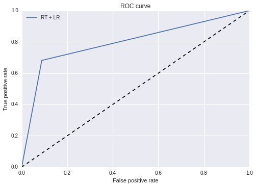

```
contato clube:
Accuracy: 0.92
Precision:  1.0
Recall:  0.3
F1-Score:  0.461538461538
---------------------------------
Confusion matrix for contato clube
Positive predictions:  3
[[80  7]
 [ 0  3]]
---------------------------------
Roc Area:  0.65
```

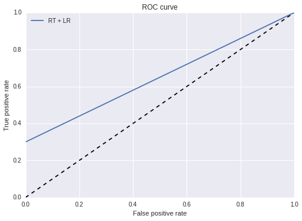

```
parceria:
Accuracy: 0.98
Precision:  1.0
Recall:  0.333333333333
F1-Score:  0.5
---------------------------------
Confusion matrix for parceria
Positive predictions:  1
[[87  2]
 [ 0  1]]
---------------------------------
Roc Area:  0.666666666667
```

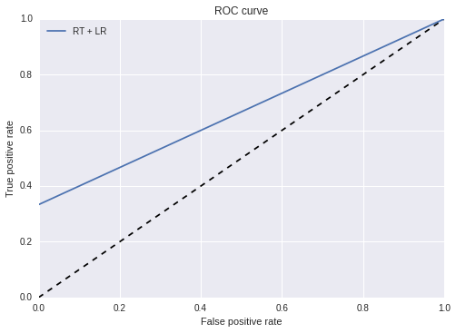

```
voluntario geral:
Accuracy: 0.81
Precision:  0.884615384615
Recall:  0.621621621622
F1-Score:  0.730158730159
---------------------------------
Confusion matrix for voluntario geral
Positive predictions:  26
[[50 14]
 [ 3 23]]
---------------------------------
Roc Area:  0.782508924018
```

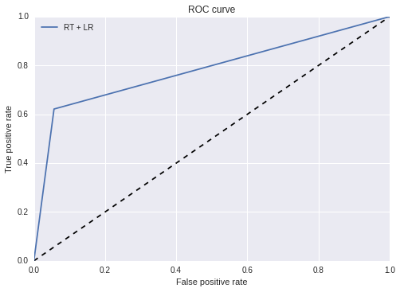

```
Local busca voluntario:
Accuracy: 0.99
Precision:  0.0
Recall:  0.0
F1-Score:  0.0
---------------------------------
Confusion matrix for Local busca voluntario
Positive predictions:  0
[[89  1]
 [ 0  0]]
---------------------------------
Roc Area:  0.5
```

```
Voluntario busca local:
Accuracy: 0.98
Precision:  0.0
Recall:  0.0
F1-Score:  0.0
---------------------------------
Confusion matrix for Voluntario busca local
Positive predictions:  0
[[88  2]
 [ 0  0]]
---------------------------------
Roc Area:  0.5
```

```
Como funciona:
Accuracy: 0.78
Precision:  0.0
Recall:  0.0
F1-Score:  0.0
---------------------------------
Confusion matrix for Como funciona
Positive predictions:  1
[[70 19]
 [ 1  0]]
---------------------------------
Roc Area:  0.492957746479
```

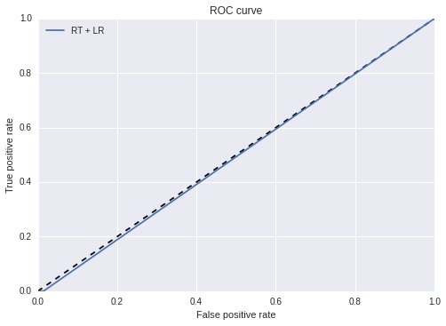

```
Apresentar projeto:
Accuracy: 0.98
Precision:  0.0
Recall:  0.0
F1-Score:  0.0
---------------------------------
Confusion matrix for Apresentar projeto
Positive predictions:  0
[[88  2]
 [ 0  0]]
---------------------------------
Roc Area:  0.5
```

```
Crianca quer clube:
Accuracy: 0.94
Precision:  0.333333333333
Recall:  0.25
F1-Score:  0.285714285714
---------------------------------
Confusion matrix for Crianca quer clube
Positive predictions:  3
[[84  3]
 [ 2  1]]
---------------------------------
Roc Area:  0.613372093023
```

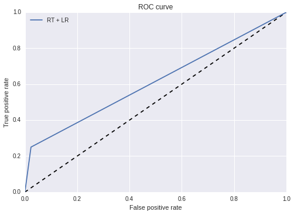

```
Material:
Accuracy: 0.89
Precision:  0.0
Recall:  0.0
F1-Score:  0.0
---------------------------------
Confusion matrix for Material
Positive predictions:  1
[[80  9]
 [ 1  0]]
---------------------------------
Roc Area:  0.493827160494
```

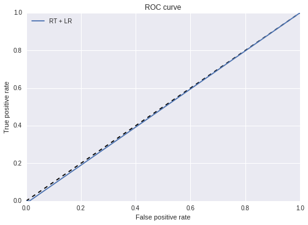

```
Precisa de um humano:
Accuracy: 0.93
Precision:  1.0
Recall:  0.4
F1-Score:  0.571428571429
---------------------------------
Confusion matrix for Precisa de um humano
Positive predictions:  4
[[80  6]
 [ 0  4]]
---------------------------------
Roc Area:  0.7
```

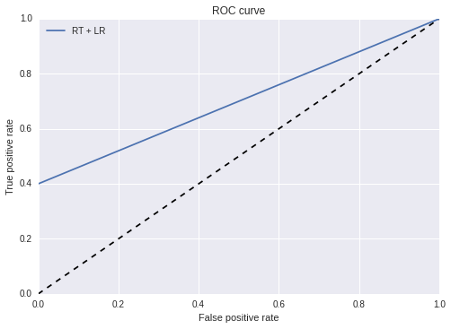

```
Treinamento:
Accuracy: 1.00
Precision:  0.0
Recall:  0.0
F1-Score:  0.0
---------------------------------
Confusion matrix for Treinamento
Positive predictions:  0
[[90]]
---------------------------------
Roc Area:  --
```

```python
#Searching best alpha
print "Searching alpha to max Global Accuracy:"
acc = 0; best_acc = 0; alfa_max = 0;
alfas = np.arange(0.1, 1.0, 0.1)
for alfa in alfas:
    gnb = MultinomialNB(alpha=alfa, fit_prior=True, class_prior=None)
    for i in range(n_classes):
        y_pred[str(emails.columns.values[i+3])] = gnb.fit(X_train.toarray(), y_train[str(emails.columns.values[i+3])]).predict(X_test.toarray())
    acc = global_accuracy(y_pred, y_test)
    if acc > best_acc:
        best_acc = acc
        alfa_max = alfa
print "Best alpha: " + str(alfa_max)
print "Best Global-Acc: " + str(best_acc)



y_pred = pd.DataFrame(index=y_test.index, columns=y_test.columns.values)
y_pred_proba = pd.DataFrame(index=y_test.index, columns=y_test.columns.values)
print "\n\nMultinomial-Naive Bayes with best alpha"
gnb = MultinomialNB(alpha=alfa_max, fit_prior=True, class_prior=None)
for i in range(n_classes):
    y_pred[str(emails.columns.values[i+3])] = gnb.fit(X_train.toarray(), y_train[str(emails.columns.values[i+3])]).predict(X_test.toarray())
    y_pred_proba[str(emails.columns.values[i+3])] = gnb.fit(X_train.toarray(), y_train[str(emails.columns.values[i+3])]).predict_proba(X_test.toarray())
    print str(emails.columns.values[i+3]) + ": %.2f" \
        % float((y_pred[str(emails.columns.values[i+3])] == y_test[str(emails.columns.values[i+3])]).sum() / float(y_test.shape[0]))

print "\n\n *** Leave One Out ***"
for i in range(n_classes):
    print str(emails.columns.values[i+3]) + ": ",
    #loo_cv(X_train.toarray(), y_train[str(emails.columns.values[i+3])], gnb)
    print "---------------------------------"

print "\n\nComplete Report"
complete_report(y_pred, y_test)
```

## Analysing e-mail text and prediction output:

```python
def show_results(y_test, y_pred, y_pred_proba, n_examples=10):
    for example in range(n_examples):
        not_predicted = []
        example_index = y_test.index[example]
        print "Assunto: " + str(emails["assunto"][example_index])
        print emails["mensagem"][example_index]
        print "\n\n*********************************"
        print "*********** Predicted ***********"
        print "*********************************"
        for i in range(n_classes):
            if y_pred[str(emails.columns.values[i+3])][example_index] == 1:
                print str(emails.columns.values[i+3]),
                if y_test[str(emails.columns.values[i+3])][example_index] == 1:
                    print "(Correct)\n",
                else:
                    print "(Incorrect)\n",
            else:
                if y_test[str(emails.columns.values[i+3])][example_index] == 1:
                    not_predicted.append(str(emails.columns.values[i+3]))
        print "*********************************\n"
        print "*********************************"
        print "********* Not Predicted *********"
        print "*********************************"
        for not_p in not_predicted:
            print not_p + "\n",
        print "*********************************\n"
        print "*********************************"
        print "********* Probabilities *********"
        print "*********************************"
        probs = dict()
        for i in range(n_classes):
            probs[str(emails.columns.values[i+3])] = 1.0 - y_pred_proba[str(emails.columns.values[i+3])][example_index]
            #print str(emails.columns.values[i+3]),
            #print 1.0 - y_pred_proba[str(emails.columns.values[i+3])][example_index]
        probs_ = sorted(probs, key=probs.__getitem__, reverse=True)
        for p in probs_:
            print p,
            print "%0.6f" % probs[p]
        print "*********************************\n\n"

show_results(y_test, y_pred, y_pred_proba)
```

```
Assunto: Code Club
Boa Tarde,
Estou cursando ciência da computação e estou interessada em ser voluntaria na CDI Escola Caetano de Campos ou em outro que seja de facil acesso  ao metro.
Obrigada, atenciosamente Thays.


*********** Predicted ***********

********* Not Predicted *********
contato clube
voluntario geral

********* Probabilities *********
voluntario geral 0.403851
Como funciona 0.261624
criar clube 0.159550
contato clube 0.150128
Material 0.059702
Voluntario busca local 0.038112
Apresentar projeto 0.024045
Precisa de um humano 0.023802
Crianca quer clube 0.022009
Treinamento 0.003465
Local busca voluntario 0.003397
parceria 0.002007


Assunto: Duvidas.
BOM DIA

GOSTARIA DE SABER COMO COLOCO MEUS FILHOS PARA INICIAR UMA ATIVIDADE DE PROGRAMAÇÃO. HÁ POSSIBILIDADE VIA WEB, COMO UM TIPO DE ENSINO A DISTANCIA? OBRIGADO PELA ATENÇÃO.


*********** Predicted ***********

********* Not Predicted *********
Crianca quer clube

********* Probabilities *********
Como funciona 0.489496
```

[output cut: 250 more lines]

```
Material

********* Probabilities *********
voluntario geral 0.313479
Como funciona 0.278225
criar clube 0.160649
Material 0.141131
Crianca quer clube 0.011306
Apresentar projeto 0.011056
Precisa de um humano 0.010248
contato clube 0.007495
parceria 0.003734
Treinamento 0.002368
Local busca voluntario 0.001007
Voluntario busca local 0.000967
```

# Changing Prediction Rules

1. The model must predict at least one label
2. The model must predict as many labels the n_label_model predicts

```python
def at_least_n_pred(n, y_pred, y_test, y_pred_proba):
    for point in range(y_pred.shape[0]):
        index = y_test.index[point]
        #print "index: ", index
        #print "Soma: ", sum(y_pred.loc[index, class_names[:-6]])
        if sum(y_pred.loc[index, class_names]) == 0:
            #print "Será arrumado: ", index
            probs = dict()
            for i in range(n_classes):
                probs[str(emails.columns.values[i+3])] = 1.0 - y_pred_proba[str(emails.columns.values[i+3])][index]
            probs_ = sorted(probs, key=probs.__getitem__, reverse=True)
            #print "Prevsao sera em: ", probs_[0]
            for i in range(n):
                y_pred[probs_[i]][index] = 1
```

```python
#Making
i = 0
#print y_pred[str(emails.columns.values[i+3])].shape
#print y_test[str(emails.columns.values[i+3])].shape
#print y_pred.shape[1]
for point in range(y_pred.shape[0]):
        index = y_test.index[point]
        #print "index: ", index
        #print "Soma: ", sum(y_pred.loc[index, class_names[:-6]])
        if sum(y_pred.loc[index, class_names]) == 0:
            print "This example will predict something now: ", index
            probs = dict()
            for i in range(n_classes):
                probs[str(emails.columns.values[i+3])] = 1.0 - y_pred_proba[str(emails.columns.values[i+3])][index]
            probs_ = sorted(probs, key=probs.__getitem__, reverse=True)
            print "The prediction will be: ", probs_[0]
            y_pred[probs_[0]][index] = 1
i = 0
#print y_pred[str(emails.columns.values[i+3])].shape
#print y_test[str(emails.columns.values[i+3])].shape
```

[output not shown]

```python
print "\n\nComplete Report"
print y_pred.shape
print y_test.shape
#complete_report(y_pred, y_test)

p = pd.DataFrame()
#print y_pred.head(5)
p["n_prev"] = y_pred.apply(lambda x : x.sum(), axis=1)
print p["n_prev"].describe()
i = 0
print str(emails.columns.values[i+3])
print y_pred[str(emails.columns.values[i+3])].shape
print y_test[str(emails.columns.values[i+3])].shape
print "Accuracy: %.2f"         % float((y_pred[str(emails.columns.values[i+3])] == y_test[str(emails.columns.values[i+3])]).sum() / float(y_test.shape[0]))
```

```
Complete Report
(90, 12)
(90, 12)
count    90.000000
mean      1.055556
std       0.274828
min       1.000000
25%       1.000000
50%       1.000000
75%       1.000000
max       3.000000
Name: n_prev, dtype: float64
criar clube
(90,)
(90,)
Accuracy: 0.79
```

```
Global Accuracy:  0.511111111111
criar clube:
Accuracy: 0.79
Precision:  0.548387096774
Recall:  0.772727272727
F1-Score:  0.641509433962
---------------------------------
Confusion matrix for criar clube
Positive predictions:  31
[[54  5]
 [14 17]]
---------------------------------
Roc Area:  0.783422459893
```

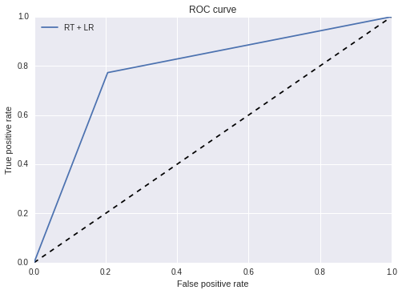

```
contato clube:
Accuracy: 0.93
Precision:  0.75
Recall:  0.6
F1-Score:  0.666666666667
---------------------------------
Confusion matrix for contato clube
Positive predictions:  8
[[78  4]
 [ 2  6]]
---------------------------------
Roc Area:  0.7875
```

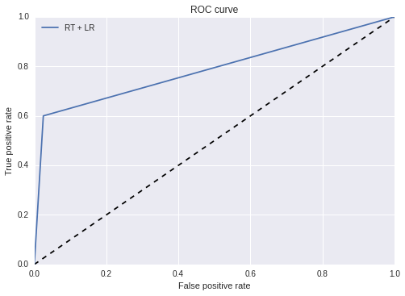

```
parceria:
Accuracy: 0.98
Precision:  1.0
Recall:  0.333333333333
F1-Score:  0.5
---------------------------------
Confusion matrix for parceria
Positive predictions:  1
[[87  2]
 [ 0  1]]
---------------------------------
Roc Area:  0.666666666667
```

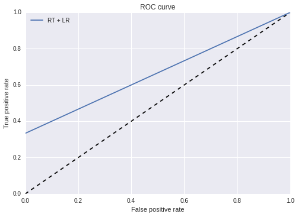

```
voluntario geral:
Accuracy: 0.84
Precision:  0.848484848485
Recall:  0.756756756757
F1-Score:  0.8
---------------------------------
Confusion matrix for voluntario geral
Positive predictions:  33
[[48  9]
 [ 5 28]]
---------------------------------
Roc Area:  0.831208567058
```

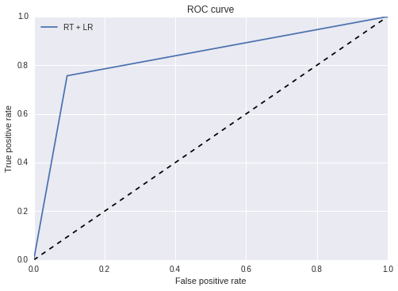

```
Local busca voluntario:
Accuracy: 0.99
Precision:  0.0
Recall:  0.0
F1-Score:  0.0
---------------------------------
Confusion matrix for Local busca voluntario
Positive predictions:  0
[[89  1]
 [ 0  0]]
---------------------------------
Roc Area:  0.5
```

```
Voluntario busca local:
Accuracy: 0.98
Precision:  0.0
Recall:  0.0
F1-Score:  0.0
---------------------------------
Confusion matrix for Voluntario busca local
Positive predictions:  0
[[88  2]
 [ 0  0]]
---------------------------------
Roc Area:  0.5
```

```
Como funciona:
Accuracy: 0.78
Precision:  0.4
Recall:  0.105263157895
F1-Score:  0.166666666667
---------------------------------
Confusion matrix for Como funciona
Positive predictions:  5
[[68 17]
 [ 3  2]]
---------------------------------
Roc Area:  0.531504818384
```

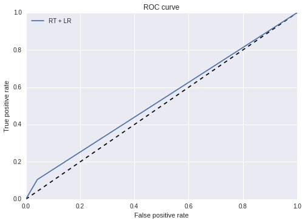

```
Apresentar projeto:
Accuracy: 0.98
Precision:  0.0
Recall:  0.0
F1-Score:  0.0
---------------------------------
Confusion matrix for Apresentar projeto
Positive predictions:  0
[[88  2]
 [ 0  0]]
---------------------------------
Roc Area:  0.5
```

```
Crianca quer clube:
Accuracy: 0.94
Precision:  0.333333333333
Recall:  0.25
F1-Score:  0.285714285714
---------------------------------
Confusion matrix for Crianca quer clube
Positive predictions:  3
[[84  3]
 [ 2  1]]
---------------------------------
Roc Area:  0.613372093023
```

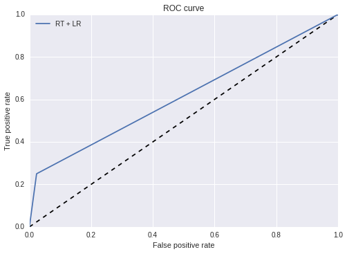

```
Material:
Accuracy: 0.88
Precision:  0.0
Recall:  0.0
F1-Score:  0.0
---------------------------------
Confusion matrix for Material
Positive predictions:  2
[[79  9]
 [ 2  0]]
---------------------------------
Roc Area:  0.487654320988
```

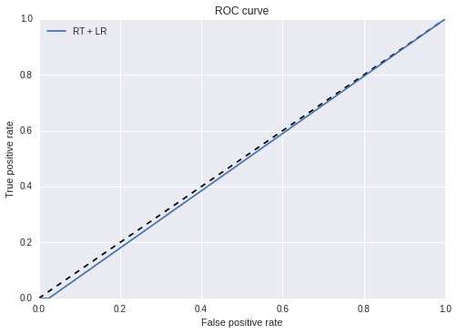

```
Precisa de um humano:
Accuracy: 0.91
Precision:  0.583333333333
Recall:  0.7
F1-Score:  0.636363636364
---------------------------------
Confusion matrix for Precisa de um humano
Positive predictions:  12
[[75  3]
 [ 5  7]]
---------------------------------
Roc Area:  0.81875
```

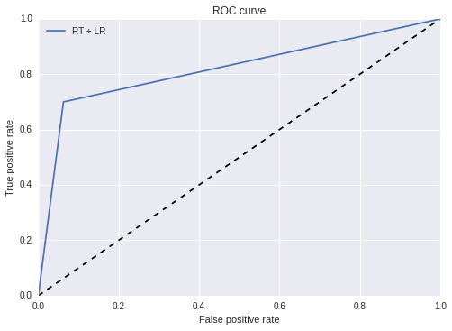

```
Treinamento:
Accuracy: 1.00
Precision:  0.0
Recall:  0.0
F1-Score:  0.0
---------------------------------
Confusion matrix for Treinamento
Positive predictions:  0
[[90]]
---------------------------------
Roc Area:  --
Assunto: Code Club
Boa Tarde,
Estou cursando ciência da computação e estou interessada em ser voluntaria na CDI Escola Caetano de Campos ou em outro que seja de facil acesso  ao metro.
Obrigada, atenciosamente Thays.


*********** Predicted ***********
voluntario geral (Correct)

********* Not Predicted *********
contato clube

********* Probabilities *********
voluntario geral 0.403851
Como funciona 0.261624
criar clube 0.159550
contato clube 0.150128
Material 0.059702
Voluntario busca local 0.038112
Apresentar projeto 0.024045
Precisa de um humano 0.023802
Crianca quer clube 0.022009
Treinamento 0.003465
Local busca voluntario 0.003397
parceria 0.002007


Assunto: Duvidas.
BOM DIA
```

[output cut: 860 more lines]

```
Voluntario busca local

********* Probabilities *********
voluntario geral 0.450638
contato clube 0.212930
Como funciona 0.208486
criar clube 0.080114
Voluntario busca local 0.048559
Apresentar projeto 0.029061
Material 0.016885
Precisa de um humano 0.008615
Treinamento 0.006503
Crianca quer clube 0.006004
parceria 0.001492
Local busca voluntario 0.001180
```

```python
complete_report(y_pred, y_test)
show_results(y_test, y_pred, y_pred_proba, n_examples=30)
```

## Predicting how many labels an example would have

- Create new features:
  - Number of words
  - Number of words square
  - Number of question marks
  - Number of end points

```
   id                                           mensagem       assunto  \
0   1  Queria informações de como me tornar um volunt...  Informações.
1   2  Boa Tarde\n\nGostaria de mais informações sobr...    Volutanrio
2   3  Olá, eu gostaria de saber como faço para que o...     Code Club
3   4  Boa tarde.\nMeu Nome é OLIVER, sou estudante, ...    Voluntário
4   5  Olá, me chamo: Roberto Padilha,\nGostaria de m...    Voluntario

   criar clube  contato clube  parceria  voluntario geral  \
0            1              0         0                 0
1            0              0         0                 1
2            0              0         0                 1
3            1              0         0                 1
4            0              0         0                 1

   Local busca voluntario  Voluntario busca local  Como funciona  \
```

[output cut: 56 more lines]

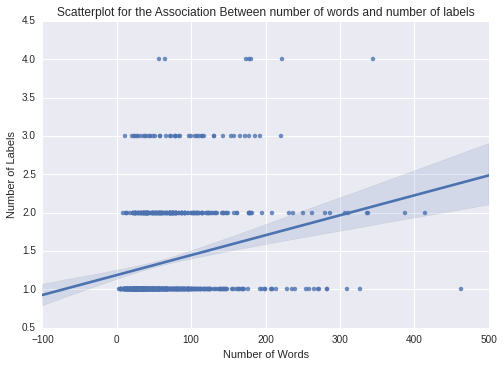

[figure not shown]

```
count    891.000000
mean       0.707071
std        1.087490
min        0.000000
25%        0.000000
50%        0.000000
75%        1.000000
max        9.000000
Name: question_marks, dtype: float64
```

```python
#target: emails["n_labels"]
#New features
emails["n_words"] = emails.apply(lambda x : len(x["clean_message"].split()), axis=1)
emails["n_words2"] = emails.apply(lambda x : pow(x["n_words"], 2), axis=1)
emails["question_marks"] = emails.apply(lambda x : len(re.findall(r'\?', x["mensagem"])), axis=1)
print emails.head(5)

scat1 = sns.regplot(x="n_words", y="n_labels", fit_reg=True, data=emails)
plt.xlabel('Number of Words')
plt.ylabel('Number of Labels')
plt.title('Scatterplot for the Association Between number of words and number of labels')
plt.show()

scat1 = sns.regplot(x="question_marks", y="n_labels", fit_reg=True, data=emails)
plt.xlabel('Number of Words')
plt.ylabel('Number of Labels')
plt.title('Scatterplot for the Association Between number of words and number of labels')
plt.show()


print emails["question_marks"].describe()
```

## Dealing with skewness

Create some different sets with differents approach to deal with skewness:

1. Undersampling
2. Oversampling

**TO DO**